# 10 First-order Logic

## 10.1 Representation Revisited

### Programming languages

**Programming language** is a kind of formal languages.

### Propositional logic

- **Propositional logic** is a **declarative language**.
  - Semantics is based on the truth relation between sentences and possible worlds.
- Propositional logic allows partial/disjunctive/negated information
  - Unlike most data structures and databases
- Propositional logic is **compositional**, which is desirable in representation languages
  - The meaning of a sentence is a function of the meaning of its parts; e.g., the meanings of $S_{1,4}\land S_{1,2}$ relates the meanings of $S_{1,4}$ and $S_{1,2}$.
- Meaning in propositional logic is **context-independent**
  - Unlike natural language, where meaning depends on context
- Propositional logic has very limited expressive power
  - E.g., cannot say “pits cause breezes in adjacent squares”

### First-order logic

Whereas propositional logic assumes world contains *facts*, first-order logic (like natural language) assumes the world contains

- **Objects**: are referred by nouns and noun phrases
  - E.g., people, houses, numbers, theories, Ronald McDonald, colors, baseball games, wars, centuries $\ldots$
- **Relations**: can be unary relations (properties) or n-ary relations, representing by verbs and verb phrases
  - Properites: red, round, bogus, prime, multistoried, etc.
  - n-ary relations: brother of, bigger than, inside, part of, has color, occurred after, owns, comes between, etc.
- **Predicates**: are relations that return true/false
- **Functions**: are relations that return object

### Logics in general

| **Language** | **Ontological Commitment** (What exists in the world) | **Epistemological Commitment** (What an agent believes about facts) |
| --- | --- | --- |
| Propositional logic | facts | true/false/unknown |
| First-order logic | facts, objects, relations | true/false/unknown |
| Temporal logic | facts, objects, relations, time | true/false/unknown |
| Probability logic | facts | degree of belief $\in[0,1]$ |
| Fuzzy logic | facts + degree of truth $\in[0,1]$ | known interval value |

## 10.2 Syntax and Semantics

### BNF Grammar

$$\begin{array}{rcl}
Sentence & \to & AtomicSentence\mid ComplexSentence\\
AtomicSentence & \to & Predicate\mid Predicate(Term,...)\mid Term_{1}=Term_{2}\\
ComplexSentence & \to & (Sentence)\mid[Sentence]\\
& | & \lnot Sentence\\
& | & Sentence\land Sentence\\
& | & Sentence\lor Sentence\\
& | & Sentence\implies Sentence\\
& | & Sentence\iff Sentence\\
& | & Quantifier\:Variable,...Sentence\\
\\Term & \to & Function(Term,...)\\
& | & Constant\\
& | & Variable\\
\\Quantifier & \to & \forall\mid\exists\\
Constant & \to & A\mid X_{1}\mid John\mid...\\
{\color{red}Variable} & \to & {\color{red}a}\mid{\color{red}x}\mid{\color{red}s}\mid...\\
{\color{green}Predicate} & \to & {\color{green}True}\mid{\color{green}False}\mid{\color{green}After}\mid{\color{green}Loves}\mid{\color{green}Raining}\mid...\\
{\color{green}Function} & \to & {\color{green}mother}\mid{\color{green}leftleg}\mid...\\
\\\text{Operator Precedence} & : & \lnot,=,\land,\lor,\implies,\iff
\end{array}$$

### Terms

**Term** is a logical expression that refers to an object

- Constants
- Functions
- Variables

**Ground term** is a term without variables

### Graph representation of a model

- A model can be represented as a directed graph.
- The following graph contains five **objects**, two **binary relations**, three **unary relations** (indicated by labels on the objects), and one **unary function**, left-leg.

[figure not shown]

### Models in First-order logic

A model $m$ in first-order logic maps:

- Constant symbols to objects $m(R)=o_{1}$ and $m(J)=o_{2}$
- Predicate/function symbols to tuples of objects

$$\begin{align*}
m({\color{green}Person}) & =\{o_{1},o_{2}\} \\
m({\color{green}King}) & =\{o_{2}\} \\
m({\color{green}Crown}) & =\{o_{5}\} \\
m({\color{green}Brother}) & =\{(o_{1},o_{2}),(o_{2},o_{1})\} \\
m({\color{green}onhead}) & =\{(o_{5},o_{2})\} \\
m({\color{green}leftleg}) & =\{(o_{1},o_{3}),(o_{2},o_{4})\} \\
\end{align*}$$

- Similar to propositional logic, entailment, validity, and so on are defined in terms of all possible models.
- The number of possible models is unbounded $\to$ checking entailment by the enumeration is **infeasible**.
- 137,506,194,466 models with six or fewer objects.

[figure not shown]

### A restriction on models

“Richard and John are people.”

$${\color{green}Person}(Richard)\land{\color{green}Person}(John)$$

[figure not shown]

- **Unique names assumption**: Each object has **at most** one constant symbol. This rules out $m_{2}$.
- **Domain closure**: Each object has **at least** one constant symbol. This rules out $m_{3}$.

**Point**: contstant symbol $\longleftrightarrow$ object

### Quantifiers

**Universal quantification**

$\forall\left\langle {\color{red}variables}\right\rangle \;\left\langle sentence\right\rangle$

$\forall{\color{red}x}\:P({\color{red}x})$ is true in a model $m$ iff $P({\color{red}x})$ is true with ${\color{red}x}$ being *each* possible object in the model

- Think conjunction: $\forall{\color{red}x}\:P({\color{red}x})$ is like $P(A)\land P(B)\land\dots$

**Existential quantification**

$\exists\left\langle {\color{red}variables}\right\rangle \;\left\langle sentence\right\rangle$

$\exists{\color{red}x}\:P({\color{red}x})$ is true in a model $m$ iff $P({\color{red}x})$ is true with ${\color{red}x}$ being *some* possible object in the model

- Think disjunction: $\exists{\color{red}x}\:P({\color{red}x})$ is like $P(A)\lor P(B)\lor\dots$

### Natural language quantifiers

- “Everyone at Berkeley is smart”

  $$\forall{\color{red}x}\;\left({\color{green}At}({\color{red}x},Berkeley)\implies{\color{green}Smart}({\color{red}x})\right)$$

  equivalent to the **conjunction** of **instantiations**

  $$\begin{array}{cl}
  & ({\color{green}At}(King\,John,Berkeley)\implies{\color{green}Smart}(King\,John))\\
  \land & ({\color{green}At}(Richard,Berkeley)\implies{\color{green}Smart}(Richard))\\
  \land & ({\color{green}At}(Berkeley,Berkeley)\implies{\color{green}Smart}(Berkeley))\\
  \land & \ldots
  \end{array}$$
- “Someone at Stanford is smart”

  $$\exists{\color{red}x}\;\left({\color{green}At}({\color{red}x},Stanford)\land{\color{green}Smart}({\color{red}x})\right)$$

  equivalent to the **disjunction** of **instantiations**

### A common mistake to avoid

1. The main connective with $\forall$ is $\implies$; mistake: using $\land$ as the main connective with $\forall$

   $\forall{\color{red}x}\;\left({\color{green}At}({\color{red}x},Berkeley)\land{\color{green}Smart}({\color{red}x})\right)$ means “Everyone is at Berkeley and everyone is smart” (**too strong** implication)
2. The main connective with $\exists$ is $\land$; mistake: using $\implies$ as the main connective with $\exists$

   $\exists{\color{red}x}\;\left({\color{green}At}({\color{red}x},Stanford)\implies{\color{green}Smart}({\color{red}x})\right)$ means “It is true even with anyone who is not at Stanford” (**too weak** implication)

### Nested quantifiers

Multiple quantifiers enable more complex sentences. **The order** of quantification is therefore very important.

- Simplest cases: Quantifiers are of the same type

  $\forall{\color{red}x}\forall{\color{red}y}\:\left({\color{green}Brother}({\color{red}x},{\color{red}y})\implies{\color{green}Sibling}({\color{red}x},{\color{red}y})\right)$

  $\forall{\color{red}x}\forall{\color{red}y}\:\left({\color{green}Sibling}({\color{red}x},{\color{red}y})\iff{\color{green}Sibling}({\color{red}y},{\color{red}x})\right)$
- Mixtures

  $\forall{\color{red}x}\exists{\color{red}y}\:{\color{green}Loves}({\color{red}x},{\color{red}y})$ $\to$ “Everybody loves somebody”

**Confusion**: can arise when two quantifiers are used with the same variable name

$$\forall{\color{red}x}\:({\color{green}Crown}({\color{red}x})\lor(\exists{\color{red}x}\:{\color{green}Brother}(Richard,{\color{red}x})))$$

**Rule**:

- The variable belongs to the **innermost** quantifier that mentions it or
- Use different variable names with nested quantifier

$$\forall{\color{red}x}\:({\color{green}Crown}({\color{red}x})\lor(\exists{\color{red}z}\:{\color{green}Brother}(Richard,{\color{red}z})))$$

### Properties of quantifiers

- Nested quantifiers

$$\begin{array}{lcr}
\forall{\color{red}x}\forall{\color{red}y}\:P({\color{red}x},{\color{red}y}) & \equiv & \forall{\color{red}y}\forall{\color{red}x}\:P({\color{red}x},{\color{red}y})\\
\exists{\color{red}x}\exists{\color{red}y}\:P({\color{red}x},{\color{red}y}) & \equiv & \exists{\color{red}y}\exists{\color{red}x}\:P({\color{red}x},{\color{red}y})\\
\exists{\color{red}x}\forall{\color{red}y}\:P({\color{red}x},{\color{red}y}) & \not\equiv & \forall{\color{red}y}\exists{\color{red}x}\:P({\color{red}x},{\color{red}y})
\end{array}$$

- De Morgan’s rules

### Equality

- $term_{1}=term_{2}$ is true under a given interpretation if and only if $term_{1}$ and $term_{2}$ refer to the same object
- $\lnot(term_{1}=term_{2})$ means $term_{1}$ and $term_{2}$ not refer to the same object (sometimes write as $term_{1}\neq term_{2}$)
- ${\color{green}father}(John)=Henry$ means that ${\color{green}father}(John)$ and $Henry$ refer to the same object

### Fun with sentences

- Brothers are siblings
  $$\forall{\color{red}x},{\color{red}y}\;\left({\color{green}Brother}({\color{red}x},{\color{red}y})\implies{\color{green}Sibling}({\color{red}x},{\color{red}y})\right)$$
- “Sibling” is symmetric
  $$\forall{\color{red}x},{\color{red}y}\;\left({\color{green}Sibling}({\color{red}x},{\color{red}y})\iff{\color{green}Sibling}({\color{red}y},{\color{red}x})\right)$$
- One’s mother is one’s female parent
  $$\forall{\color{red}x},{\color{red}y}\;\left({\color{green}Mother}({\color{red}x},{\color{red}y})\iff({\color{green}Female}({\color{red}x})\land{\color{green}Parent}({\color{red}x},{\color{red}y}))\right)$$
- A first cousin is a child of a parent’s sibling
  $$\forall{\color{red}x},{\color{red}y}\;\left({\color{green}FirstCousin}({\color{red}x},{\color{red}y})\iff\exists{\color{red}p},{\color{red}ps}\;\left({\color{green}Parent}({\color{red}p},{\color{red}x})\land{\color{green}Sibling}({\color{red}ps},{\color{red}p})\land{\color{green}Parent}({\color{red}ps},{\color{red}y})\right)\right)$$

## 10.3 Applications

### Using First-Order Logic

First-order knowledge base $KB$ has // interface

- Sentences (**assertions**) are added to a knowledge base $KB$ using $\text{Tell}$
  - $\text{Tell}(KB,{\color{green}King}(John))$
  - $\text{Tell}(KB,{\color{green}Person}(Richard))$
  - $\text{Tell}(KB,\forall{\color{red}x}\:({\color{green}King}({\color{red}x})\implies{\color{green}Person}({\color{red}x})))$
- We can ask questions (**queries** or **goals**) of the knowledge base $KB$ using $\text{Ask}$
  - $\text{Ask}(KB,{\color{green}Person}(John))$ $\to$ return true
  - $\text{Ask}(KB,\exists{\color{red}x}\:{\color{green}Person}({\color{red}x}))$ $\to$ return true
- If we want to know what value of ${\color{red}x}$ makes the sentence true using $\text{AskVars}$
  - $\text{AskVars}(KB,{\color{green}Person}({\color{red}x}))$ $\to$ return a **substitution** list $\left\{{\color{red}x}/John\right\}$ and $\left\{{\color{red}x}/Richard\right\}$
- The assertions can be considered as the **axioms**
- Logical sentences which are entailed by the axioms are called **theorems**
- The theorems do not increase the set of conclusions that follow from the knowledge base $KB$

From a practical point of view, theorems are essential to reduce the computational cost of deriving new sentences

### The Kinship Domain

- Unary predicates
  - Male and Female
- Binary predicates represent kinship relations
  - Parenthood, brotherhood, marriage, etc.
  - Parent, Sibling, Brother , Sister, Child, Daughter, Son, Spouse, Wife, Husband, Grandparent , Grandchild , Cousin, Aunt, and Uncle.
- Functions
  - Mother and Father, each person has exactly one of each of these.

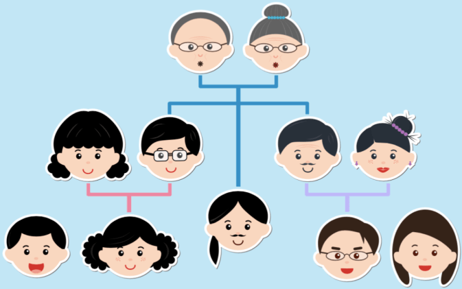

### The Little Kinship Domain

The possible axioms for Kinship domain

1. One’s mother is one’s female parent
   $$\forall m,c\,({\color{green}mother}(c)=m\iff{\color{green}Female}(m)\land{\color{green}Parent}(m,c)).$$
2. One’s husband is one’s male spouse
   $$\forall w,h\,({\color{green}Husband}(h,w)\iff{\color{green}Male}(h)\land{\color{green}Spouse}(h,w)).$$
3. Male and female are disjoint categories
   $$\forall x\,({\color{green}Male}(x)\iff\lnot{\color{green}Female}(x)).$$
4. Parent and child are inverse relations
   $$\forall p,c\,({\color{green}Parent}(p,c)\iff{\color{green}Child}(c,p)).$$
5. A grandparent is a parent of one’s parent
   $$\forall g,c\,({\color{green}GrandParent}(g,c)\iff\exists p\;{\color{green}Parent}(g,p)\land{\color{green}Parent}(p,c)).$$
6. A sibling is another child of one’s parents
   $$\forall x,y\,({\color{green}Sibling}(x,y)\iff x\neq y\land\exists p\;{\color{green}Parent}(p,x)\land{\color{green}Parent}(p,y)).$$

Using axioms to entail theorems

$$\text{axioms of kinship}\models\forall x\forall y\:({\color{green}Sibling}(x,y)\iff{\color{green}Sibling}(y,x))$$

### Natural number theory

- To present the theory of **natural numbers**, we need
  - a predicate ${\color{green}NatNum}$ that will be true of natural numbers
  - one constant symbol, 0
  - one function symbol, ${\color{green}s}$ (successor)
  - one addition function, $\mathbin{\color{green}+}$
- The **Peano axioms** define natural numbers and addition. Natural numbers are defined recursively
  1. ${\color{green}NatNum}(0)$
  2. $\forall n\,({\color{green}NatNum}(n)\implies{\color{green}NatNum}(S(n)))$
  3. $\forall n\,(0\neq{\color{green}s}(n))$
  4. $\forall m,n\,(m\neq n\implies{\color{green}s}(m)\neq{\color{green}s}(n))$
  5. $\forall m\,(0\neq{\color{green}NatNum}(m)\implies\mathbin{\color{green}+}(0,m)=m)$
  6. $\forall m,n\,({\color{green}NatNum}(m)\land{\color{green}NatNum}(n)\implies\mathbin{\color{green}+}({\color{green}s}(m),n)={\color{green}s}(\mathbin{\color{green}+}(m,n)))$

### Set theory

One possible **set of axioms** is as follows

1. The only sets are the empty set and those made by adjoining something to a set
   $$\forall s\,\left({\color{green}Set}(s)\iff\left(s=\emptyset\right)\lor\left(\exists x,s_{2}\,{\color{green}Set}(s_{2})\land s=\left\{ x\mid s_{2}\right\} \right)\right)$$
2. The empty set has no elements adjoined into it. In other words, there is no way to decompose $\emptyset$ into a smaller set and an element
   $$\lnot\exists x,s\;\left\{ x\mid s\right\} =\emptyset.$$
3. Adjoining an element already in the set has no effect
   $$\forall x,s\;x\in s\iff s=\left\{ x\mid s\right\} .$$
4. The only members of a set are the elements that were adjoined into it. We express this recursively, saying that $x$ is a member of $s$ if and only if $s$ is equal to some set $s_{2}$ adjoined with some element $y$, where either $y$ is the same as $x$ or $x$ is a member of $s_{2}$
   $$\forall x,s\;\left(x\in s\iff\exists y,s_{2}\left(s=\left\{ y\mid s_{2}\right\} \land\left(x=y\lor x\in s_{2}\right)\right)\right).$$
5. A set $s_{1}$ is a subset of another set $s_{2}$ if and only if all of the first set’s members are members of the second set
   $$\forall s_{1},s_{2}\,\left(s_{1}\subseteq s_{2}\iff(\forall x\;x\in s_{1}\Rightarrow x\in s_{2})\right).$$
6. Two sets $s_{1}$ and $s_{2}$ are equal if and only if each is a subset of the other
   $$\forall s_{1},s_{2}\,\left(s_{1}=s_{2}\iff(s_{1}\subseteq s_{2}\land s_{2}\subseteq s_{1})\right).$$
7. An object $x$ is in the intersection of two sets $s_{1}$ and $s_{2}$ if and only if it is a member of both sets
   $$\forall x,s_{1},s_{2}\,\left(x\in(s_{1}\cap s_{2})\iff(x\in s_{1}\land x\in s_{2})\right).$$
8. An object $x$ is in the union of two sets $s_{1}$ and $s_{2}$ if and only if it is a member of either set
   $$\forall x,s_{1},s_{2}\,\left(x\in(s_{1}\cup s_{2})\iff(x\in s_{1}\lor x\in s_{2})\right).$$

### Knowledge base for the wumpus world

- The corresponding first-order sentence stored in the knowledge base must include both the $percept$ and the time $t$ at which it occurred
- The actions in the wumpus world are also represented by logical terms

[figure not shown]

**Agent**

- **Perception**:
  - $Percept([s,b,g,m,c],t),Stench(t),Breeze(t),Glitter(t)$
  - $\text{Tell}(KB,\forall t,s,g,m,c \;Percept\left([s,Breeze,g,m,c],t\right)\implies Breeze(t))$
  - $\text{Tell}(KB,\forall t,s,b,m,c \;Percept\left([s,b,Glitter,m,c],t\right)\implies Glitter(t))$
  - $\text{Tell}(KB,Percept([Stench,Breeze,Glitter,None,None],5))$
- **Action**:
  - $TurnRight,TurnLeft,Forward,Shoot,Grab,Climb,BestAction$
  - For simple “reflex” behavior $\text{Tell}(KB,\forall t\:(Glitter(t)\implies BestAction(Grab,t)))$
  - To determine which is best, the agent program executes the query $\text{AskVars}(KB,\exists a\:BestAction(a,t))$

**Environment**

$\begin{array}{l} \text{Tell}(KB,\forall x,y,a,b\:(Adjacent([x,y],[a,b])\iff \\ (x=a\land(y=b-1\lor y=b+1))\lor(y=b\land(x=a-1\lor x=a+1)))) \end{array}$

$\text{Tell}(KB,\forall x,s_{1},s_{2},t\:(At(x,s_{1},t)\land At(x,s_{2},t)\implies s_{1}=s_2))$

$\text{Tell}(KB,\forall s,t\:(At(Agent,s,t)\land Breeze(t)\implies Breezy(s)))$

$\text{Tell}(KB,\forall s\:(Breezy(s)\iff\exists r\:Adjacent(r,s)\land Pit(r)))$

## 10.4 Simple Inference

### A brief history of reasoning

| 450B.C. | Stoics |
| --- | --- |
| 322B.C. | Aristotle |
| 1965 | Robinson |

### Substitution

A substitution $\theta$ is a mapping from variables to terms. $\text{Subst}[\theta,\alpha]$ returns the result of performing substitution $\theta$ on $\alpha$. Note that: $\text{Subst}[\theta,\alpha]$ also written as $\alpha\theta$.

- $\text{Subst}(\ \{{\color{red}x}/alice\},{\color{green}P}({\color{red}x}))={\color{green}P}(alice)$
- $\text{Subst}(\ \{{\color{red}x}/alice,{\color{red}y}/{\color{red}z}\},{\color{green}P}({\color{red}x})\land{\color{green}Q}({\color{red}x},{\color{red}y}))={\color{green}P}(alice)\land{\color{green}Q}(alice,{\color{red}z})$

### Skolem normal form

A sentence of first-order logic is in **Skolem normal form** if it is written as a string of quantifiers and variables (with only universal first-order quantifiers) followed by a quantifier-free part.

- Every first-order sentence may be converted into Skolem normal form while not changing its satisfiability.

### Universal instantiation (UI)

Every instantiation of a universally quantified sentence is entailed by it
$$\frac{\forall{\color{red}x}\\ \alpha}{\text{Subst}(\ \{{\color{red}x}/g\},\alpha)}$$
for any variable ${\color{red}x}$ and **ground term** $g$ (a term without variables)

$$\begin{align*}
& \forall{\color{red}x}\:({\color{green}King}({\color{red}x})\land{\color{green}Greedy}({\color{red}x})\implies{\color{green}Evil}({\color{red}x}))\models\\
& King\text{-}John\land Greedy\text{-}John\implies Evil\text{-}John\\
& King\text{-}Richard\land Greedy\text{-}Richard\implies Evil\text{-}Richard\\
& King\text{-}Father\text{-}John\land Greedy\text{-}Father\text{-}John\implies Evil\text{-}Father\text{-}John
\end{align*}$$

### Existential instantiation (EI)

For any sentence $\alpha$, variable ${\color{red}x}$, and constant symbol $k$ (**skolem constant**) *that does not appear elsewhere in the knowledge base*
$$\frac{\exists{\color{red}x}\\ \alpha}{\text{Subst}(\ \{{\color{red}x}/k\},\alpha)}$$

$$\exists{\color{red}x}\:({\color{green}Crown}({\color{red}x})\land{\color{green}OnHead}({\color{red}x},John))\models{\color{green}Crown}(C_{1})\land{\color{green}OnHead}(C_{1},John)$$
provided $C_{1}$ is a new constant symbol

- The logic equivalence
  $$\forall{\color{red}x}\,\exists{\color{red}y}\,{\color{green}R}({\color{red}x},{\color{red}y})\Longleftrightarrow\exists{\color{red}y}\,\forall{\color{red}x}\,{\color{green}R}({\color{red}x},{\color{green}f}({\color{red}x}))$$
  where ${\color{green}f}({\color{red}x})$ is a function that maps ${\color{red}x}$ to ${\color{red}y}$.

For any sentence $\alpha$, variable ${\color{red}x},{\color{red}y}$, and and function ${\color{green}f}$ (**skolem function**)
$$\frac{\forall{\color{red}x}\,\exists{\color{red}y}\,\alpha}{\text{Subst}(\ \{{\color{red}y}/{\color{green}f}({\color{red}x})\},\alpha)}$$

### UI vs. EI

- UI can be applied several times to *add* new sentences; the new $KB$ is logically equivalent to the old
- EI can be applied once to *replace* the existential sentence; the new $KB$ is *not* equivalent to the old, but it can be shown to be **inferentially equivalent** (the new $KB$ is satisfiable iff the old $KB$ was satisfiable)

### Propositionalization

- Knowledge base $KB$ in first-order logic

  $$\begin{array}{l}
  {\color{green}King}(John)\\
  {\color{green}Greedy}(John)\\
  {\color{green}Brother}(Richard,John).\forall{\color{red}x}\:({\color{green}King}({\color{red}x})\land{\color{green}Greedy}({\color{red}x})\implies{\color{green}Evil}({\color{red}x}))
  \end{array}$$

$$\downarrow\;\text{(Instantiating)}$$

- Knowledge base in propositional logic

  $$\begin{array}{l}
  King\text{-}John\\
  Greedy\text{-}John\\
  Brother\text{-}Richard\text{-}John\\
  King\text{-}John\land Greedy\text{-}John\implies Evil\text{-}John\\
  King\text{-}Richard\land Greedy\text{-}Richard\implies Evil\text{-}Richard
  \end{array}$$
- **Claim**: A ground sentence is entailed by new $KB$ iff entailed by original $KB$
- **Claim**: Every FOL $KB$ can be propositionalized so as to preserve entailment
- **Idea**: Propositionalize $KB$ and query, apply resolution, return result
- **Problem**: with function symbols, there are infinitely many ground terms,
  - E.g., ${\color{green}father}({\color{green}father}({\color{green}father}(John)))$

**Theorem (Herbrand, 1930)**

If a sentence $\alpha$ is entailed by an FOL $KB$, it is entailed by a *finite* subset of the propositionalization of $KB$

- **Idea:**

  ```
  for n = 0 to ∞ do
      create a propositional KB by instantiating with
      depth-n terms see if α is entailed by this KB
  ```

- **Problem**: works if $\alpha$ is entailed, loops if $\alpha$ is not entailed

**Theorem (Turing, 1936; Church, 1936)**

Entailment in FOL is **semidecidable**

- Algorithms exist that say yes to every entailed sentence, but no algorithm exists that also says no to every non-entailed sentence.

### Problems with propositionalization

- Propositionalization seems to generate lots of **irrelevant** sentences. For example,

  $$\begin{align*}
  & {\color{green}King}(John)\\
  & {\color{green}Brother}(Richard,John)\\
  & \forall{\color{red}x}\:{\color{green}Greedy}({\color{red}x})\\
  & \forall{\color{red}x}\:({\color{green}King}({\color{red}x})\land{\color{green}Greedy}({\color{red}x})\implies{\color{green}Evil}({\color{red}x}))
  \end{align*}$$

  it seems obvious that $Evil\text{-}John$, but propositionalization produces lots of facts such as $Greedy\text{-}Richard$ that are irrelevant
- With $p$ $k$-ary predicates and $n$ constants, there are $p\cdot n^{k}$ instantiations
- With function symbols, it gets nuch much worse!

## 10.5 Unification

### Unification

**Unification** is a process to find substitutions $\theta$ that make different logical expressions $p$ and $q$ look identical. $\text{Unify}(p,q)=\theta$ where $\text{Subst}(\theta,p)=\text{Subst}(\theta,q)$

| $p$ | $q$ | $\theta$ |
| --- | --- | --- |
| ${\color{green}Knows}(John,{\color{red}x})$ | ${\color{green}Knows}(John,Jane)$ | $\{{\color{red}x}/Jane\}$ |
| ${\color{green}Knows}(John,{\color{red}x})$ | ${\color{green}Knows}({\color{red}y},Mary)$ | $\{{\color{red}x}/Mary,{\color{red}y}/John\}$ |
| ${\color{green}Knows}(John,{\color{red}x})$ | ${\color{green}Knows}({\color{red}y},{\color{green}mother}({\color{red}y}))$ | $\{{\color{red}y}/John,{\color{red}x}/{\color{green}mother}(John)\}$ |
| ${\color{green}Knows}(John,{\color{red}x})$ | ${\color{green}Knows}({\color{red}x},Mary)$ | $fail$ |

### Most General Unifier (MGU)

- Consider the unification $\text{Unify}({\color{green}Knows}(John,{\color{red}x}),{\color{green}Knows}({\color{red}y},{\color{red}z}))$, the results could be
  - $\theta_{1}=\{{\color{red}y}/John,{\color{red}x}/z\}$
  - $\theta_{2}=\{{\color{red}y}/John,{\color{red}x}/John,{\color{red}z}/John\}$ The first unifier $\theta_{1}$ is more general than the second $\theta_{2}$
- There is a single **Most General Unifier** (MGU) that is unique up to renaming of variables
  $$\theta_{MGU}=\{{\color{red}y}/John,{\color{red}x}/{\color{red}z}\}$$

### The unification algorithm

```
function Unify(s1, s2, θ) returns a substitution to make s1 and s2 identical

inputs: s1, a variable, constant, list, or compound
        s2, a variable, constant, list, or compound
        θ, the substitution built up so far (optional, defaults to empty)

    if θ = failure then
        return failure
    else if s1 = s2 then
        return θ
    else if Variable?(s1)
        then return Unify-Var(s1, s2, θ)
    else if Variable?(s2)
        then return Unify-Var(s2, s1, θ)
    else if Compound?(s1) and Compound?(s2)
        then return Unify(s1.Args, s2.Args, Unify(s1.Op, s2.Op, θ))
    else if List?(s1) and List?(s2) then
        return Unify(s1.Rest, s2.rest, Unify(s1.First, s2.First, θ))
    else return failure

function Unify-Var(var, s, θ) returns a substitution

    if {var/val} in θ then return Unify(val, s, θ)
    else if {s/val} in θ then return Unify(var, val, θ)
    else if Occur-Check?(var, s) then return failure
    else return add {var/s} to θ
```

### Occur Check

- Given $\text{Unify-Var}({\color{red}var}$, $s$) return failure if where ${\color{red}var}$ occurs in $s$ and $s$ is not a variable
- For example, $\text{Unify-Var}({\color{red}x}$, ${\color{green}father}({\color{red}x})$) cannot be unified.

### Quiz: Unification

| $p$ | $q$ | $\theta$ |
| --- | --- | --- |
| ${\color{green}P}({\color{green}f}(A),{\color{green}g}({\color{red}x}))$ | ${\color{green}P}({\color{red}y},{\color{red}y})$ |  |
| ${\color{green}P}(A,{\color{red}x},{\color{green}h}({\color{green}g}({\color{red}z})))$ | ${\color{green}P}({\color{red}z},{\color{green}h}({\color{red}y}),{\color{green}h}({\color{red}y}))$ |  |
| ${\color{green}P}({\color{red}x},{\color{green}f}({\color{red}x}),{\color{red}z})$ | ${\color{green}P}({\color{green}g}({\color{red}y}),{\color{green}f}({\color{green}g}(B)),{\color{red}y})$ |  |
| ${\color{green}P}({\color{red}x},{\color{green}f}({\color{red}x}))$ | ${\color{green}P}({\color{green}f}({\color{red}y}),{\color{red}y})$ |  |
| ${\color{green}P}({\color{red}x},{\color{green}f}({\color{red}z}))$ | ${\color{green}P}({\color{green}f}({\color{red}y}),{\color{red}y})$ |  |

## 10.6 Forward Chaining

### First-order definite clauses

- **A definite clause** is a disjunctions of literals of which exactly one is positive. It is
  - an atomic or
  - an implication whose antecedent is a conjunctions of positive literals and consequent is a positive literal
- **A first-order literal** can include variables, which are assumed to be *universally quantified*

$$\begin{array}{l}
{\color{green}King}({\color{red}x})\land{\color{green}Greedy}({\color{red}x})\Rightarrow{\color{green}Evil}({\color{red}x})\\
{\color{green}King}(John)\\
{\color{green}Greedy}({\color{red}y})
\end{array}$$

- **Datalog** = first-order definite clauses + *no functions*

### Generalized Modus Ponens (GMP)

**Generalized Modus Ponens** For atomic sentences $p_{i}$, $p_{i}^{\prime}$, and $q$, where there is a substitution $\theta$ such that $\text{Subst}(\theta,p_{i}^{\prime})=\text{Subst}(\theta,p_{i})$, for all $i$
$$\dfrac{p_{1}^{\prime},p_{2}^{\prime},...,p_{n}^{\prime},\left(p_{1}\land p_{2}\land...\land p_{n}\Rightarrow q\right)}{\text{Subst}(\theta,q)}$$

For example

| $p_{1}^{\prime}$ is ${\color{green}King}(John)$ | $p_{1}$ is ${\color{green}King}({\color{red}x})$ |
| --- | --- |
| $p_{2}^{\prime}$ is ${\color{green}Greedy}({\color{red}y})$ | $p_{2}$ is ${\color{green}Greedy}({\color{red}x})$ |
|  | $q$ is ${\color{green}Evil}({\color{red}x})$ |
| $\theta$ is $\left\{ {\color{red}x}/John,{\color{red}y}/John\right\}$ | $\text{Subst}(\theta,q)$ is $Evil\text{-}John$ |

### Soundness of GMP

**Lemma**

For any definite clause $p$, we have $p\models p\theta$ by UI

**Proof** Need to show that
$$p_{1}^{\prime},\ldots,p_{n}^{\prime},(p_{1}\land\ldots\land p_{n}\Rightarrow q)\models q\theta$$
provided that $p_{i}^{\prime}\theta=p_{i}\theta$ for all $i$

1. $(p_{1}\land\ldots\land p_{n}\Rightarrow q)\models(p_{1}\land\ldots\land p_{n}\Rightarrow q)\theta=(p_{1}\theta\land\ldots\land p_{n}\theta\Rightarrow q\theta)$
2. $p_{1}^{\prime},\ldots,p_{n}^{\prime}\models p_{1}^{\prime}\land\ldots\land p_{n}^{\prime}\models p_{1}^{\prime}\theta\land\ldots\land p_{n}^{\prime}\theta$
3. From 1 and 2, $q\theta$ follows by ordinary Modus Ponens

### Example 1

**Problem**

The law says that it is a crime for an American to sell weapons to hostile nations. The country Nono, an enemy of America, has some missiles, and all of its missiles were sold to it by Colonel West, who is American.

**Prove that** Colonel West is a criminal?

- … it is a crime for an American to sell weapons to hostile nations

$${\color{green}American}({\color{red}x})\land{\color{green}Weapon}({\color{red}y})\land{\color{green}Sells}({\color{red}x},{\color{red}y},{\color{red}z})\land{\color{green}Hostile}({\color{red}z})\implies{\color{green}Criminal}({\color{red}x})$$

- Nono … has some missiles

$${\color{green}Owns}(Nono,{\color{red}x})\land{\color{green}Missile}({\color{red}x})$$

- … all of its missiles were sold to it by Colonel West

  $${\color{green}Missile}({\color{red}x})\land{\color{green}Owns}(Nono,{\color{red}x})\implies{\color{green}Sells}(West,{\color{red}x},Nono)$$
- Missiles are weapons

  $${\color{green}Missile}({\color{red}x})\implies{\color{green}Weapon}({\color{red}x})$$
- An enemy of America counts as “hostile”

  $${\color{green}Enemy}({\color{red}x},America)\implies{\color{green}Hostile}({\color{red}x})$$
- West, who is American …

  $${\color{green}American}(West)$$
- The country Nono, an enemy of America …

  $${\color{green}Enemy}(Nono,America)$$
- … and Colonel West is American

  $${\color{green}American}(West)$$

### Forward chaining algorithm

```
function FOL-FC-Ask(KB, α) returns a substitution or false

    repeat
        new ← ⌀

        for each rule in KB do
            (p1 ∧ … ∧ pn ⇒ q) ← Standardize-Variables(rule)

            for each substitution θ such that
                for all i, Subst(θ, pi) unifies with some fact in KB do

                q′ ← Subst(θ, q)

                if no sentence in KB ∪ new unifies with q′ then
                    add q′ to new

                    φ ← Unify(q′, α)
                    if φ ≠ fail then
                        return φ

        add all sentences in new to KB
    until new = ⌀

    return false
```

### Forward chaining proof

[figure not shown]

### Example 2

**Problem**

- Art is the father of Bob and Bud.
- Bob is the father of Cal and Coe.
- Grandfather is the father of a father.

**Question** Is Art the grandfather of Coe?

Convert English sentences into FOL sentences

| # | FOL sentence | explain |
| --- | --- | --- |
| 1 | ${\color{green}F}(Art,Bob)$ | KB |
| 2 | ${\color{green}F}(Art,Bud)$ | KB |
| 3 | ${\color{green}F}(Bob,Cal)$ | KB |
| 4 | ${\color{green}F}(Bob,Coe)$ | KB |
| 5 | ${\color{green}F}({\color{red}x},{\color{red}y})\land{\color{green}F}({\color{red}y},{\color{red}z})\implies{\color{green}G}({\color{red}x},{\color{red}z})$ | KB |
| 6 | ${\color{green}G}(Art,Coe)$ | 1,4,5 $\left\{{\color{red}x}/Art,{\color{red}y}/Bob,{\color{red}z}/Coe\right\}$ |

### Properties of forward chaining

- **Sound**:
  - YES, every inference is just an application of GMP
- **Complete**:
  - YES for definite clause knowledge bases
  - It answers every query whose answers are entailed by any $KB$ of definite clauses
- It terminates for Datalog in poly iterations: at most $p\cdot n^{k}$ literals
- It may not terminate in general if $\alpha$ is not entailed
  - This is unavoidable: entailment with definite clauses is **semidecidable**

### Efficiency of forward chaining

- **Simple observation**: no need to match a rule on iteration $k$ if a premise wasn’t added on iteration $k-1$ $\to$ match each rule whose premise contains a newly added literal
- Matching itself can be expensive
- **Database indexing** allows $O(1)$ retrieval of known facts E.g., query ${\color{green}Missile}({\color{red}x})$ retrieves ${\color{green}Missile}(M_{1})$
- Matching conjunctive premises against known facts is NP-hard
- Forward chaining is widely used in **deductive databases**

### Definite clauses with function symbols

- Inference can explode forward and may never terminate.
- Consider the following KB with two predicates and two functions

$$\begin{array}{l}
{\color{green}Even}(2)\\
{\color{green}Even}({\color{red}x})\implies{\color{green}Even}({\color{green}plus}({\color{red}x},2))\\
{\color{green}Integer}({\color{red}x})\implies{\color{green}Even}({\color{green}times}({\color{red}x},2))\\
{\color{green}Even}({\color{red}x})\implies{\color{green}Integer}({\color{red}x})
\end{array}$$

[figure not shown]

### Quiz: Forward chaining

- Given a KB containing the following sentence

  ${\color{green}Parent}({\color{red}x},{\color{red}y})\land{\color{green}Male}({\color{red}x})\implies{\color{green}Father}({\color{red}x},{\color{red}y})$

  ${\color{green}Father}({\color{red}x},{\color{red}y})\land{\color{green}Father}({\color{red}x},{\color{red}z})\implies{\color{green}Sibling}({\color{red}y},{\color{red}z})$

  ${\color{green}Male}(Tom)$

  ${\color{green}Parent}(Tom,John)$

  ${\color{green}Parent}(Tom,Fred)$
- Perform the forward chaining until a fixed point is reached.

## 10.7 Backward Chaining

### A backward-chaining algorithm

```
function FOL-BC-Ask(KB, query) returns a generator of substitutions
    return FOL-BC-Or(KB, query, {})

generator FOL-BC-Or(KB, goal, θ) yields a substitution
    for each rule (lhs ⇒ rhs) in Fetch-Rules-For-Goal(KB, goal) do
        (lhs, rhs) ← Standardize-Variables((lhs, rhs))
        θ1 ← Unify(rhs, goal, θ)
        if θ1 ≠ failure then
            for each θ2 in FOL-BC-And(KB, lhs, θ1) do
                yield θ2

generator FOL-BC-And(KB, goals, θ) yields a substitution
    if θ = failure then return
    else if goals is empty then
        yield θ
    else
        first ← First(goals)
        rest ← Rest(goals)
        for each θ1 in FOL-BC-Or(KB, Subst(θ, first), θ) do
            for each θ2 in FOL-BC-And(KB, Subst(θ1, rest), θ1) do
                yield θ2
```

### Backward chaining example

[figure not shown]

### Properties of backward chaining

- Depth-first recursive proof search
  - space is linear in size of proof
- Incomplete due to infinite loops
  - fix by checking current goal against every goal on stack
- Inefficient due to repeated subgoals (both success and failure)
  - fix using caching of previous results (extra space!)
- Widely used for **logic programming**

## 10.8 Resolution

### Conversion to CNF

A sentence “Everyone who loves all animals is loved by someone” is represented by

$$\forall{\color{red}x}[[\forall{\color{red}y}[{\color{green}Animal}({\color{red}y})\implies{\color{green}Loves}({\color{red}x},{\color{red}y})]]\implies[\exists{\color{red}z}\:{\color{green}Loves}({\color{red}z},{\color{red}x})]]$$

1. Standardize variables: each quantifier should use a different one

   $$\forall{\color{red}x}[[\forall{\color{red}y}[{\color{green}Animal}({\color{red}y})\implies{\color{green}Loves}({\color{red}x},{\color{red}y})]]\implies[\exists{\color{red}z}\:{\color{green}Loves}({\color{red}z},{\color{red}x})]]$$
2. Eliminate biconditionals and implications

   $$\forall{\color{red}x}[[\lnot\forall{\color{red}y}\:[\lnot{\color{green}Animal}({\color{red}y})\lor{\color{green}Loves}({\color{red}x},{\color{red}y})]]\lor[\exists{\color{red}z}\:{\color{green}Loves}({\color{red}z},{\color{red}x})]]$$
3. Move $\lnot$ inwards:

   $$\forall{\color{red}x}[[{\color{green}Animal}({\color{green}F}({\color{red}x}))\land\lnot{\color{green}Loves}({\color{red}x},{\color{green}f}({\color{red}x}))]\lor{\color{green}Loves}({\color{green}g}({\color{red}x}),{\color{red}x})$$
5. Drop universal quantifiers

   $$[{\color{green}Animal}({\color{green}f}({\color{red}x}))\land\lnot{\color{green}Loves}({\color{red}x},{\color{green}f}({\color{red}x}))]\lor{\color{green}Loves}({\color{green}g}({\color{red}x}),{\color{red}x})$$
6. Distribute $\land$ over $\lor$

   $$[{\color{green}Animal}({\color{green}f}({\color{red}x}))\lor{\color{green}Loves}({\color{green}g}({\color{red}x}),{\color{red}x})]\land[\lnot{\color{green}Loves}({\color{red}x},{\color{green}f}({\color{red}x}))\lor{\color{green}Loves}({\color{green}g}({\color{red}x}),{\color{red}x})]$$

### Generalized Resolution

Full first-order version
$$\begin{equation}
\frac{\ell_{1}\lor\cdots\lor{\color{red}\ell_{i}}\lor\cdots\lor\ell_{k},\qquad m_{1}\lor\cdots\lor{\color{green}{\color{orange}m_{j}}}\lor\cdots\lor m_{n}}{(\ell_{1}\lor\cdots\lor\ell_{i-1}\lor\ell_{i+1}\lor\cdots\lor\ell_{k}\lor m_{1}\lor\cdots\lor m_{j-1}\lor m_{j+1}\lor\cdots\lor m_{n})\theta}
\end{equation}$$
where $\text{Unify}({\color{red}\ell_{i}},\lnot{\color{green}{\color{orange}m_{j}}})=\theta$.

$$\frac{\begin{array}{l}
{\color{green}\lnot Rich}({\color{red}x})\lor{\color{green}Unhappy}({\color{red}x}),\qquad{\color{green}Rich}(Ken)\end{array}}{\begin{array}{l}
{\color{green}Unhappy}(Ken)\end{array}}$$
with $\theta=\{{\color{red}x}/Ken\}$

### Solution to Example 1

[figure not shown]

### Solution to Example 2

| # | FOL clause | explain |
| --- | --- | --- |
| 1 | ${\color{green}F}(Art,Bob)$ | KB |
| 2 | ${\color{green}F}(Art,Bud)$ | KB |
| 3 | ${\color{green}F}(Bob,Cal)$ | KB |
| 4 | ${\color{green}F}(Bob,Coe)$ | KB |
| 5 | $\lnot{\color{green}F}({\color{red}x},{\color{red}y})\lor\lnot{\color{green}F}({\color{red}y},{\color{red}z})\lor{\color{green}G}({\color{red}x},{\color{red}z})$ | KB |
| 6 | $\lnot{\color{green}G}(Art,Coe)$ | $\lnot\alpha$ |
| 7 | $\lnot{\color{green}F}(Art,{\color{red}y})\lor\lnot{\color{green}F}({\color{red}y},Code)$ | 5,6 $\left\{{\color{red}x}/Art,{\color{red}z}/Coe\right\}$ |
| 8 | $\lnot{\color{green}F}(Art,Bob)$ | 4,7 $\left\{{\color{red}y}/Bob\right\}$ |
| 9 | $\emptyset$ | 1,8 |

### Example 3

**Problem**

Everyone who loves all animals is loved by someone. Anyone who kills an animal is loved by no one. Jack loves all animals. Either Jack or Curiosity killed the cat, who is named Tuna. Did Curiosity kill the cat?

### Solution to Example 3

Extract simple sentences from the problem

1. Everyone who loves animals is loved by someone.
2. Anyone who kills an animal is loved by no one.
3. Jack loves all animals.
4. Either Jack or Curiosity killed the cat.
5. The cat is named Tuna.
6. Cats are animals.
7. Did Curiosity kill the cat?

Convert to FOL sentences

1. $\forall{\color{red}x}[[\forall{\color{red}y}{\color{green}Animal}({\color{red}y})\implies{\color{green}Loves}({\color{red}x},{\color{red}y})]\implies\exists{\color{red}z}{\color{green}Loves}({\color{red}z},{\color{red}x})]$
2. $\forall{\color{red}x}[[\exists{\color{red}y}{\color{green}Animal}({\color{red}y})\land{\color{green}Kills}({\color{red}x},{\color{red}y})]\implies\forall{\color{red}z}\lnot{\color{green}Loves}({\color{red}z},{\color{red}x})]$
3. $\forall{\color{red}x}[{\color{green}Animal}({\color{red}x})\implies{\color{green}Loves}(Jack,{\color{red}x})]$
4. ${\color{green}Kills}(Jack,Tuna)\lor{\color{green}Kills}(Curiosity,Tuna)$
5. ${\color{green}Cat}(Tuna)$
6. $\forall{\color{red}x}[{\color{green}Cat}({\color{red}x})\implies{\color{green}Animal}(x)]$
7. $\lnot{\color{green}Kills}(Curiosity,Tuna)$

Convert to CNF sentences

Using resolution to prove that Curiosity killed the cat

[figure not shown]

> Suppose Curiosity did not kill Tuna. We know that either Jack or Curiosity did; thus Jack must have. Now, Tuna is a cat and cats are animals, so Tuna is an animal. Because anyone who kills an animal is loved by no one, we know that no one loves Jack. On the other hand, Jack loves all animals, so someone loves him; so we have a contradiction. Therefore, Curiosity killed the cat.

### Exercise

Given a KB of the following sentences

- Anyone whom Mary loves is a football star.
- Any student who does not pass does not play.
- John is a student.
- Any student who does not study does not pass.
- Anyone who does not play is not a football star.

**Prove that** “If John does not study, Mary does not love John”

## 10.9 References